# Ex02 Estimation

Samuel Hudec

25 septembra 2018

Odhadovanie parametrov regresného modelu sa môže zdať ako jednoznačná a jednoduchá úloha. Zdanie budí hlavne “krásne” riešenie metódy najmenších štvorcov zvané aj **Normal equations**, ktoré je zhodné s riešením metódy maximalnej vierohodnosti. Najprv pripomeňme model
$$y=X\beta + \epsilon$$
ktorého odhad parametrov je
$$\hat\beta = (X'X)^{-1}X'y.$$

Všimnite si, vo výsledku je istá numerická *nepríjemnosť* a to inverzia matice $X'X$. Presne kvôli tomuto používa každý štatistický software na odhady regresných parametrov už pri obyčajnom linearnom regresnom modeli rôzne numerické metódy.

Aké rozdelenie pravdepodobnosti má $\hat\beta$?

## Jednoduchý gausovský regresný model

Vezmime dataset `mpg` a pre toto cvičenie berme ako odozvu (vysvetlovanú premennú) `hwy` a prediktor (vysvetľujúcu premennú) `displ`.

```r
# zavoláme knižnice
library(faraway)
library(car)
library(ggplot2)

# načítame dáta
data(mpg)
```

#### Odhad parametrov

Spočítajte pomocou metódy najemnších štvorcov odhady parametrov jednoduchého gausovského regresného modelu
$$hwy = a + b.displ+ \epsilon$$
.

```
##                      estimate
## intercept           35.697651
## engine displacement -3.530589
```

#### Odhad variancie

Pomocou rovnakých operácií spočítajte $\hat\sigma^2$.

```
##          [,1]
## [1,] 14.58901
```

#### Overenie normality

Overte normalitu reziduálov (odhad $\hat\epsilon$) pomocou qq plotu a krivky hustoty.

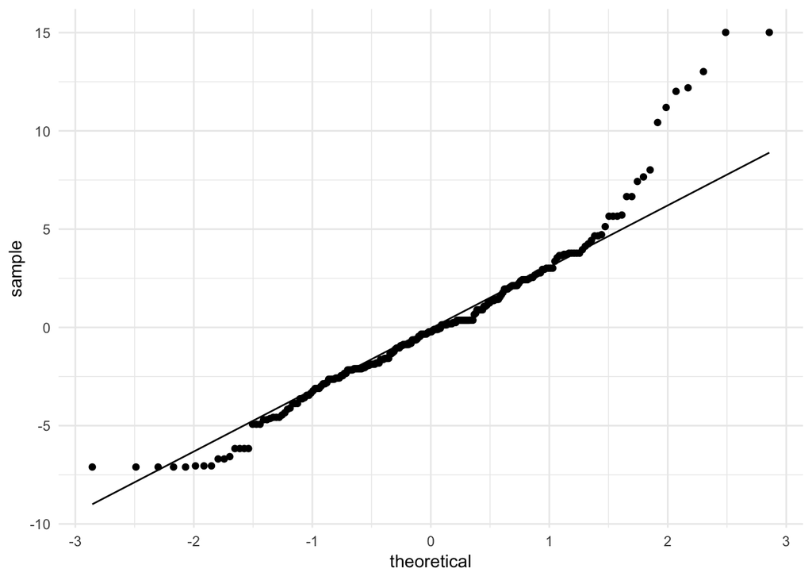

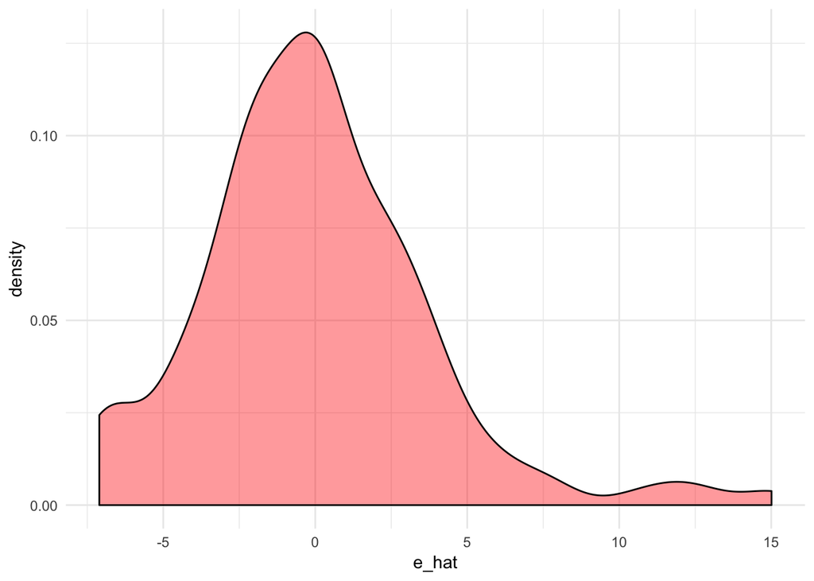

#### Použitie implementovanej funkcie

Skontrolujte vaše výsledky s funkciou `lm()`, výstup z funkcie uložte do osobitnej premennej zvanej “objekt” a na tento objekt zavolajte funkciu `summary()`. Pokúste sa interpretovať výstup.

```
##
## Call:
## lm(formula = hwy ~ displ, data = mpg)
##
## Residuals:
##     Min      1Q  Median      3Q     Max
## -7.1039 -2.1646 -0.2242  2.0589 15.0105
##
## Coefficients:
##             Estimate Std. Error t value Pr(>|t|)
## (Intercept)  35.6977     0.7204   49.55   <2e-16 ***
## displ        -3.5306     0.1945  -18.15   <2e-16 ***
## ---
## Signif. codes:  0 '***' 0.001 '**' 0.01 '*' 0.05 '.' 0.1 ' ' 1
##
## Residual standard error: 3.836 on 232 degrees of freedom
## Multiple R-squared:  0.5868, Adjusted R-squared:  0.585
## F-statistic: 329.5 on 1 and 232 DF,  p-value: < 2.2e-16
```

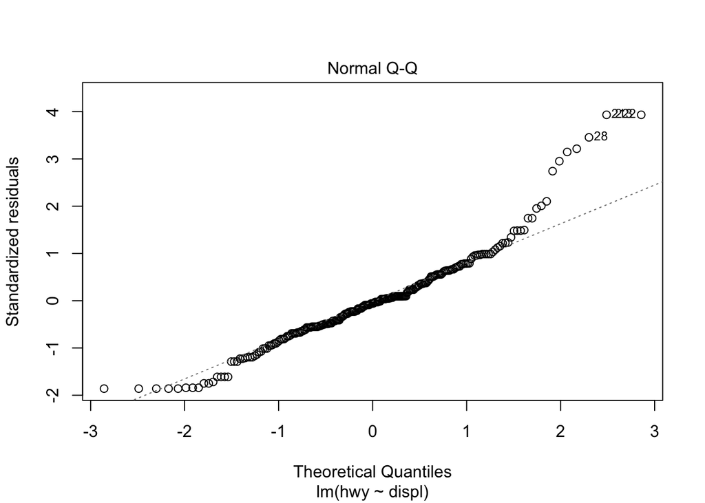

#### Zakreslenie

Zakreslite regresnú priamku do dát. Napríklad môžete pokračovať s obrázkom z domácej úlohy a vkresliť do neho regresnú priamku pomocou funkcie `geom_abline()`.

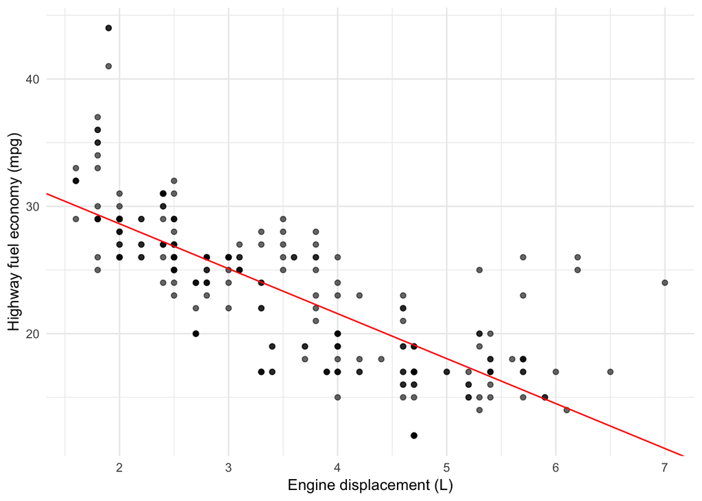

#### Záver

Interpretujte obrázok.

## Samostatná práca

Pokúsme sa dať dohromady znalosti z predchádzajúcich cvičení a fitnime model do dát `cheddar`. To vyžaduje nasledovné kroky:

1. Urobte “hrubú” obhliadku dát (oboznámenie sa s problematikou, popisná štatistika a jednoduchá vizualizácia).
2. Fitnite do dát plný regresný model s `taste` ako odozvou, pričom použite funkciu `lm()`.
3. Spočítajte mocninu korelácie medzi fitom $\hat y$ a odozvou $y$, nájdite tento údaj v `summary()` a vysvetlite ho.
4. Fitnite rovnaký model ako v 2., ale vynechajte intercept. Čo znamená hodnota $R^2$?.